# Permutational variable importance for white wine quality dataset

## About the dataset

Wine quality dataset, available at: https://archive.ics.uci.edu/ml/datasets/wine+quality connects a quality score of wine (1-10) with 11 continous attributes of its physiochemical properties:

- fixed acidity
- volatile acidity
- citric acid
- residual sugar
- chlorides
- free sulfur dioxide
- total sulfur dioxide
- density
- pH
- sulphates
- alcohol

It contains data on both: red and white wine. I assume that quality predictors would be different for either, so I've arbitraily decided to focus on the white wine.

## Used regressors

The prediction of wine quality can be interpreted as both: classification and regression task. I chose to treat it as the latter.

Since in previous homeworks *Random Forrest* seemed to always outperform other models, I've chosen to train multiple RF Regressors, for which I would shuffle the training data (80% of the original puddle). This way I had multiple models with quite similiar MSE on the test dataset. This way, 20 models were trained, of which 5 were selected.

## Permutational feature importance

To calculate feature importance I've used the metric implemented in scikitlearn.

To make the image more clear I've decided to print out only features of which feature importance was greater than 0.1

### RF 1

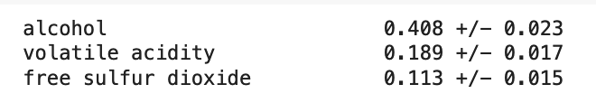

### RF 2

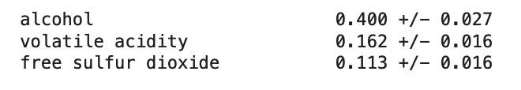

### RF 3

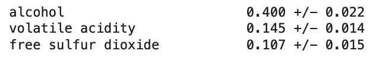

### RF 4

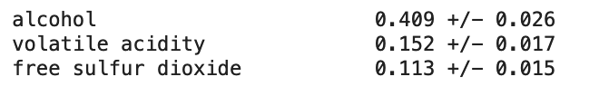

### RF 5

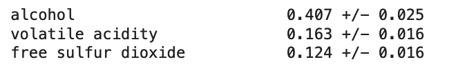

As can be seen above, all of the models presented very similiar feature importance scores. In all of the models only the same three displayed features had importance over 0.1, that is alcohol, volatile acidity and free sulfur dioxide.

Unquestionably, alcohol is the most important feature of all. This is consistent with the analysis made throughout previous homeworks.

The consistency of the feature appearance suggest, that those three features are in fact correlated with the quality score in the space of gathered data. This results stand as argument, that the models are in fact observing the real dependencies in the data instead of luckily randomly assigning the score, which in such imbalanced task (most wines scoring 6-7) is a real concern.

# Appendix

## Packages

```python
import pandas as pd
from sklearn.ensemble import RandomForestRegressor
from sklearn.inspection import permutation_importance
from sklearn.metrics import mean_squared_error
from sklearn.model_selection import train_test_split
import numpy as np
```

## Getting the data

```python
!wget https://archive.ics.uci.edu/ml/machine-learning-databases/wine-quality/winequality-white.csv
```

```
--2022-05-04 19:35:09--  https://archive.ics.uci.edu/ml/machine-learning-databases/wine-quality/winequality-white.csv
Resolving archive.ics.uci.edu (archive.ics.uci.edu)... 128.195.10.252
Connecting to archive.ics.uci.edu (archive.ics.uci.edu)|128.195.10.252|:443... connected.
HTTP request sent, awaiting response... 200 OK
Length: 264426 (258K) [application/x-httpd-php]
Saving to: ‘winequality-white.csv.1’

winequality-white.c 100%[===================>] 258.23K   946KB/s    in 0.3s

2022-05-04 19:35:09 (946 KB/s) - ‘winequality-white.csv.1’ saved [264426/264426]
```

```python
X = pd.read_csv('/content/winequality-white.csv', sep=';')
Y = pd.DataFrame(X.iloc[:,-1])
X = X.iloc[:,:-1]
```

## Preprocessing

```python
x_train, x_test, y_train, y_test = train_test_split(X, Y, test_size=0.2, random_state=0)

x_train = x_train.reset_index(drop=True)
x_test = x_test.reset_index(drop=True)
y_train = y_train.reset_index(drop=True)
y_test = y_test.reset_index(drop=True)
```

```python
x_train.head(5)
```

|  | fixed acidity | volatile acidity | citric acid | residual sugar | chlorides | free sulfur dioxide | total sulfur dioxide | density | pH | sulphates | alcohol |
| --- | --- | --- | --- | --- | --- | --- | --- | --- | --- | --- | --- |
| 0 | 7.2 | 0.26 | 0.32 | 10.4 | 0.062 | 23.0 | 114.0 | 0.99660 | 3.23 | 0.49 | 10.5 |
| 1 | 5.4 | 0.29 | 0.38 | 1.2 | 0.029 | 31.0 | 132.0 | 0.98895 | 3.28 | 0.36 | 12.4 |
| 2 | 6.5 | 0.46 | 0.31 | 5.0 | 0.027 | 15.0 | 72.0 | 0.99165 | 3.26 | 0.60 | 11.5 |
| 3 | 6.7 | 0.34 | 0.30 | 15.6 | 0.054 | 51.0 | 196.0 | 0.99820 | 3.19 | 0.49 | 9.3 |
| 4 | 6.1 | 0.16 | 0.27 | 12.6 | 0.064 | 63.0 | 162.0 | 0.99940 | 3.66 | 0.43 | 8.9 |

## Training and selection of Random Forest Regressors

### Selection

```python
num_regressors = 20
```

```python
for i in range(num_regressors):
  x_train_r, x_test_r, y_train_r, y_test_r = train_test_split(x_train, y_train, test_size=0.2, random_state=8*i)

  x_train_r = x_train_r.reset_index(drop=True)
  x_test_r = x_test_r.reset_index(drop=True)
  y_train_r = y_train_r.reset_index(drop=True)
  y_test_r = y_test_r.reset_index(drop=True)

  wwine_rf = RandomForestRegressor(max_depth=128)
  wwine_rf.fit(x_train_r, y_train_r['quality'].values)
  rf_preds = wwine_rf.predict(x_test)

  mse = mean_squared_error(y_test, rf_preds)

  print(f"RF {i}: MSE = {mse}")
```

```
RF 0: MSE = 0.49804448979591837
RF 1: MSE = 0.5071225510204083
RF 2: MSE = 0.4975626530612245
RF 3: MSE = 0.5106686734693878
RF 4: MSE = 0.5095711224489795
RF 5: MSE = 0.5097521428571429
RF 6: MSE = 0.49673173469387755
RF 7: MSE = 0.4970836734693877
RF 8: MSE = 0.5014644897959184
RF 9: MSE = 0.48396989795918366
RF 10: MSE = 0.5001325510204081
RF 11: MSE = 0.48873265306122454
RF 12: MSE = 0.49682591836734696
RF 13: MSE = 0.4921567346938775
RF 14: MSE = 0.48853489795918364
RF 15: MSE = 0.5127532653061224
RF 16: MSE = 0.49819214285714286
RF 17: MSE = 0.4960176530612245
RF 18: MSE = 0.5062757142857143
RF 19: MSE = 0.48351795918367346
```

All models have similiar mse, so I will check wheather by chance some models are more similiar to each other

```python
indices = []

for i in range(num_regressors):
  x_train_r, x_test_r, y_train_r, y_test_r = train_test_split(x_train, y_train, test_size=0.2, random_state=8*i)
  indices.append(x_train_r.index.values)
```

```python
sum([1 for x in indices[0] if x in indices[1]])/len(indices[0])
```

```
0.8021697511167837
```

```python
sim_scores = np.zeros((num_regressors, num_regressors))

for i in range(num_regressors):
  for j in range(i, num_regressors):
    sim_scores[i,j] = sum([1 for x in indices[i] if x in indices[j]])/len(indices[i])
    sim_scores[j,i] = sum([1 for x in indices[i] if x in indices[j]])/len(indices[i])
```

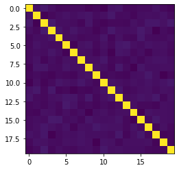

```python
from matplotlib import pylab

pylab.imshow(sim_scores)
```

All the models are similiary different, thus I will choose roughly by the best mse scores, that is models: 19, 14, 11, 9, 2

### Training od the selected

```python
x_train_r, x_test_r, y_train_r, y_test_r = train_test_split(x_train, y_train, test_size=0.2, random_state=8*19)

x_train_r = x_train_r.reset_index(drop=True)
x_test_r = x_test_r.reset_index(drop=True)
y_train_r = y_train_r.reset_index(drop=True)
y_test_r = y_test_r.reset_index(drop=True)

rf1 = RandomForestRegressor(max_depth=128)
rf1.fit(x_train_r, y_train_r['quality'].values)
```

```
RandomForestRegressor(max_depth=128)
```

```python
x_train_r, x_test_r, y_train_r, y_test_r = train_test_split(x_train, y_train, test_size=0.2, random_state=8*14)

x_train_r = x_train_r.reset_index(drop=True)
x_test_r = x_test_r.reset_index(drop=True)
y_train_r = y_train_r.reset_index(drop=True)
y_test_r = y_test_r.reset_index(drop=True)

rf2 = RandomForestRegressor(max_depth=128)
rf2.fit(x_train_r, y_train_r['quality'].values)
```

```
RandomForestRegressor(max_depth=128)
```

```python
x_train_r, x_test_r, y_train_r, y_test_r = train_test_split(x_train, y_train, test_size=0.2, random_state=8*11)

x_train_r = x_train_r.reset_index(drop=True)
x_test_r = x_test_r.reset_index(drop=True)
y_train_r = y_train_r.reset_index(drop=True)
y_test_r = y_test_r.reset_index(drop=True)

rf3 = RandomForestRegressor(max_depth=128)
rf3.fit(x_train_r, y_train_r['quality'].values)
```

```
RandomForestRegressor(max_depth=128)
```

```python
x_train_r, x_test_r, y_train_r, y_test_r = train_test_split(x_train, y_train, test_size=0.2, random_state=8*9)

x_train_r = x_train_r.reset_index(drop=True)
x_test_r = x_test_r.reset_index(drop=True)
y_train_r = y_train_r.reset_index(drop=True)
y_test_r = y_test_r.reset_index(drop=True)

rf4 = RandomForestRegressor(max_depth=128)
rf4.fit(x_train_r, y_train_r['quality'].values)
```

```
RandomForestRegressor(max_depth=128)
```

```python
x_train_r, x_test_r, y_train_r, y_test_r = train_test_split(x_train, y_train, test_size=0.2, random_state=8*2)

x_train_r = x_train_r.reset_index(drop=True)
x_test_r = x_test_r.reset_index(drop=True)
y_train_r = y_train_r.reset_index(drop=True)
y_test_r = y_test_r.reset_index(drop=True)

rf5 = RandomForestRegressor(max_depth=128)
rf5.fit(x_train_r, y_train_r['quality'].values)
```

```
RandomForestRegressor(max_depth=128)
```

## Explenations

### RF 1

```python
r1 = permutation_importance(rf1, x_test, y_test, n_repeats=30, random_state=0)
```

```python
for i in r1.importances_mean.argsort()[::-1]:
  if r1.importances_mean[i] > 0.1:
    print(f"{x_train.columns[i]:<30}"
          f"{r1.importances_mean[i]:.3f}"
          f" +/- {r1.importances_std[i]:.3f}")
```

```
alcohol                       0.408 +/- 0.023
volatile acidity              0.189 +/- 0.017
free sulfur dioxide           0.113 +/- 0.015
```

### RF 2

```python
r2 = permutation_importance(rf2, x_test, y_test, n_repeats=30, random_state=0)
```

```python
for i in r2.importances_mean.argsort()[::-1]:
  if r2.importances_mean[i] > 0.1:
    print(f"{x_train.columns[i]:<30}"
          f"{r2.importances_mean[i]:.3f}"
          f" +/- {r2.importances_std[i]:.3f}")
```

```
alcohol                       0.400 +/- 0.027
volatile acidity              0.162 +/- 0.016
free sulfur dioxide           0.113 +/- 0.016
```

### RF 3

```python
r3 = permutation_importance(rf3, x_test, y_test, n_repeats=30, random_state=0)
```

```python
for i in r3.importances_mean.argsort()[::-1]:
  if r3.importances_mean[i] > 0.1:
    print(f"{x_train.columns[i]:<30}"
          f"{r3.importances_mean[i]:.3f}"
          f" +/- {r3.importances_std[i]:.3f}")
```

```
alcohol                       0.400 +/- 0.022
volatile acidity              0.145 +/- 0.014
free sulfur dioxide           0.107 +/- 0.015
```

### RF 4

```python
r4 = permutation_importance(rf4, x_test, y_test, n_repeats=30, random_state=0)
```

```python
for i in r4.importances_mean.argsort()[::-1]:
  if r4.importances_mean[i] > 0.1:
    print(f"{x_train.columns[i]:<30}"
          f"{r4.importances_mean[i]:.3f}"
          f" +/- {r4.importances_std[i]:.3f}")
```

```
alcohol                       0.409 +/- 0.026
volatile acidity              0.152 +/- 0.017
free sulfur dioxide           0.113 +/- 0.015
```

### RF 5

```python
r5 = permutation_importance(rf5, x_test, y_test, n_repeats=30, random_state=0)
```

```python
for i in r5.importances_mean.argsort()[::-1]:
  if r5.importances_mean[i] > 0.1:
    print(f"{x_train.columns[i]:<30}"
          f"{r5.importances_mean[i]:.3f}"
          f" +/- {r5.importances_std[i]:.3f}")
```

```
alcohol                       0.407 +/- 0.025
volatile acidity              0.163 +/- 0.016
free sulfur dioxide           0.124 +/- 0.016
```